# Machine Learning Project

```r
# Suppress dplyr summarise grouping warning messages
options(dplyr.summarise.inform = FALSE)

## Add R libraries here
library(tidyverse)
library(tidymodels)
library(vip)
library(rpart.plot)

# Load the dataset
telecom_df <- read_rds(url('https://gmubusinessanalytics.netlify.app/data/telecom_df.rds'))
```

```r
telecom_df
```

```
## # A tibble: 1,175 x 19
##    canceled_service senior_citizen spouse_partner dependents cellular_service
##    <fct>            <fct>          <fct>          <fct>      <fct>
##  1 no               no             no             no         single_line
##  2 no               no             yes            yes        single_line
##  3 no               no             yes            no         multiple_lines
##  4 yes              yes            yes            no         multiple_lines
##  5 no               no             no             yes        multiple_lines
##  6 no               yes            no             no         single_line
##  7 no               yes            yes            no         multiple_lines
##  8 no               no             no             no         multiple_lines
##  9 no               no             yes            yes        single_line
## 10 no               yes            yes            yes        multiple_lines
## # ... with 1,165 more rows, and 14 more variables: avg_call_mins <dbl>,
## #   avg_intl_mins <dbl>, internet_service <fct>, online_security <fct>,
## #   online_backup <fct>, device_protection <fct>, tech_support <fct>,
## #   streaming_tv <fct>, streaming_movies <fct>, contract <fct>,
## #   paperless_bill <fct>, payment_method <fct>, months_with_company <dbl>,
## #   monthly_charges <dbl>
```

# Question 1

**Question**: Is there a relation between service cancellation and average monthly international calls?

**Answer**: Yes, the data indicates that the customers who cancel the telecommunication service tend to have a lesser average monthly duration of international calls when compared to those who do not. Among 427 customers who cancel the service, the mean average monthly international call duration was 93.57 minutes. This is around 20 minutes less than the mean of average international call minutes of customers who do not cancel the service.

Among the customers who did not cancel the service, 29% have an average monthly international call minute that is less than or equal to 95 minutes. When looking at customers who did cancel the service, this increased to 49%.

```r
telecom_df %>% group_by(canceled_service) %>%
               summarise(Num_Customers = n(),
                            Min_Intl_mins = min(avg_intl_mins),
                            Avg_Intl_mins = mean(avg_intl_mins),
                            Max_Intl_mins = max(avg_intl_mins),
                            SD_Intl_mins = sd(avg_intl_mins),
                            Perc_greater_mins = mean(avg_intl_mins <= 95))
```

```
## # A tibble: 2 x 7
##   canceled_service Num_Customers Min_Intl_mins Avg_Intl_mins Max_Intl_mins
##   <fct>                    <int>         <dbl>         <dbl>         <dbl>
## 1 yes                        427            15          93.6           168
## 2 no                         748            34         113.            231
## # ... with 2 more variables: SD_Intl_mins <dbl>, Perc_greater_mins <dbl>
```

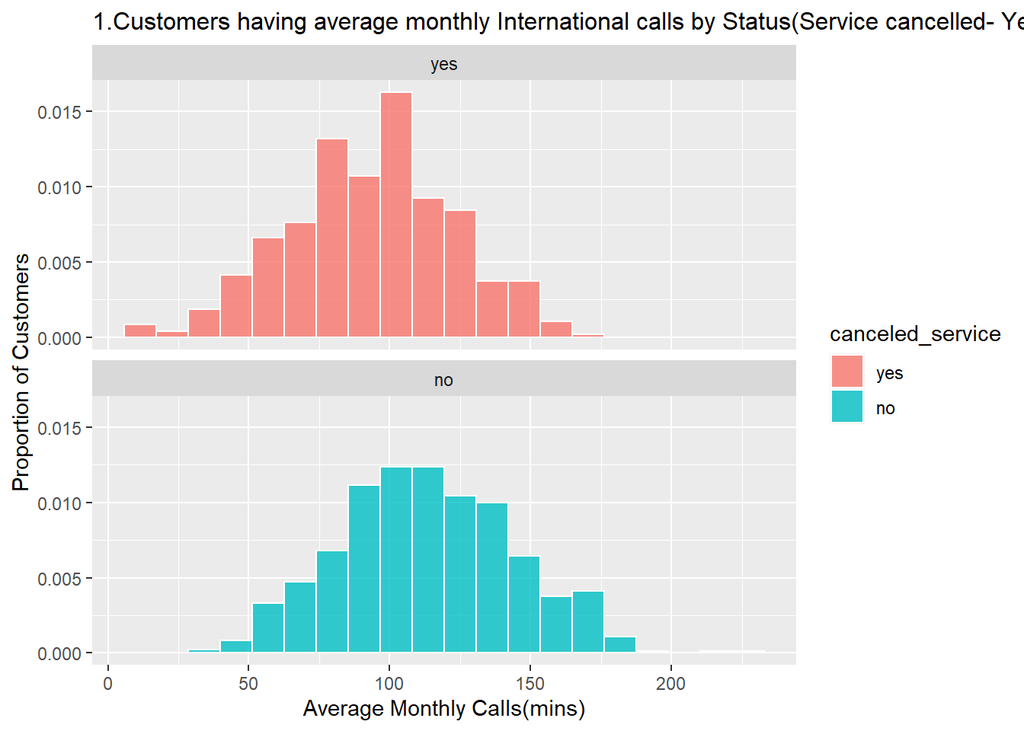

```r
ggplot(data = telecom_df, aes(x = avg_intl_mins, fill = canceled_service)) +
   geom_histogram(aes(y = ..density..), color = "white", bins = 20, alpha=0.8) +
   facet_wrap(~ canceled_service, nrow = 2) +
   labs(title = "1.Customers having average monthly International calls by Status(Service cancelled- Yes/No)",
           x = "Average Monthly Calls(mins)", y = "Proportion of Customers") +
   theme(plot.title = element_text(size = 12))
```

It is visible from the above histogram plot 1 that the majority of customers who did cancel the service have an average monthly international call minutes less than 100.

# Question 2

**Question**: Is there a relation between service cancellation and household dependents?

```r
telecom_df %>% group_by(canceled_service, dependents) %>%
                  summarise(Num_Customers = n()) %>%
                  group_by(dependents) %>%
                  mutate(Total_Cust_Dependents = sum(Num_Customers),
                  Perc_Cust_Depen = round(Num_Customers/Total_Cust_Dependents, 2))
```

```
## # A tibble: 4 x 5
## # Groups:   dependents [2]
##   canceled_service dependents Num_Customers Total_Cust_Dependen~ Perc_Cust_Depen
##   <fct>            <fct>              <int>                <int>           <dbl>
## 1 yes              yes                   86                  297           0.290
## 2 yes              no                   341                  878           0.39
## 3 no               yes                  211                  297           0.71
## 4 no               no                   537                  878           0.61
```

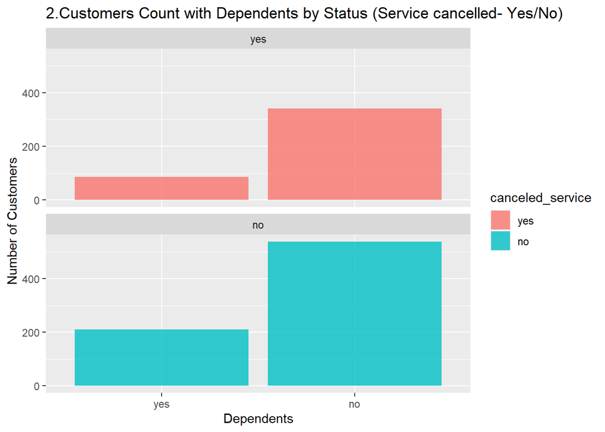

```r
telecom_df %>% group_by(canceled_service, dependents) %>%
                  summarise(Num_Customers = n()) %>%
                  ggplot(aes(dependents, Num_Customers, fill = canceled_service)) + geom_bar(stat = "identity", alpha=0.8) +
                  facet_wrap(~ canceled_service, nrow = 2) +
                  labs(title = "2.Customers Count with Dependents by Status (Service cancelled- Yes/No)",
                  x = "Dependents", y = "Number of Customers")
```

The above bar plot 2 illustrates that the count of customers who did not cancel the service either with or without dependents is higher when compared to customers who did cancel the service.

# Question 3

**Question**: Is there a relation between service cancellation and total number of months with company?

**Answer**: Yes, the data specifies that the customers who cancel the service tend to remain fewer months with the company than those who do not. Among 427 customers who cancel the service, the average total number of months remained with the company is around 17. This is around 21 months less than the average number of months who remained with the company and did not cancel the service.

Among the customers who did not cancel the service, 24.19% of them remained less than or equal to 15 months with the company. When looking at customers who did cancel the service, this increased to 60.88%.

```r
telecom_df %>% group_by(canceled_service) %>%
               summarise(Num_Customers = n(),
                            Min_Intl_mins = min(months_with_company),
                            Avg_Intl_mins = mean(months_with_company),
                            Max_Intl_mins = max(months_with_company),
                            SD_Intl_mins = sd(months_with_company),
                            pct_months = mean(months_with_company <= 15))
```

```
## # A tibble: 2 x 7
##   canceled_service Num_Customers Min_Intl_mins Avg_Intl_mins Max_Intl_mins
##   <fct>                    <int>         <dbl>         <dbl>         <dbl>
## 1 yes                        427             1          17.7            72
## 2 no                         748             1          38.7            72
## # ... with 2 more variables: SD_Intl_mins <dbl>, pct_months <dbl>
```

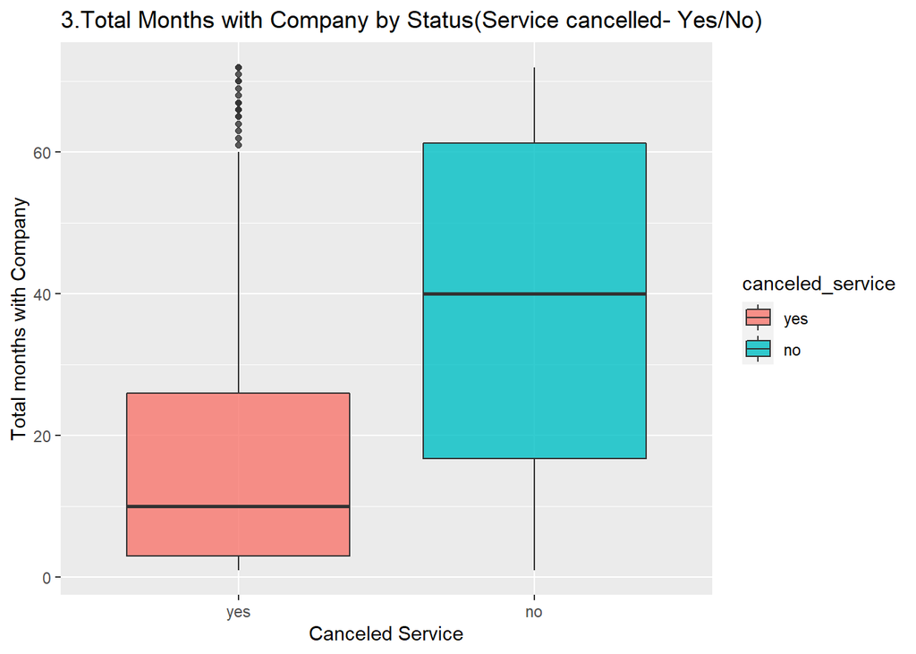

```r
ggplot(data = telecom_df, aes(canceled_service, months_with_company, fill = canceled_service)) +
  geom_boxplot(alpha=0.8) + labs(title = "3.Total Months with Company by Status(Service cancelled- Yes/No)",
           x = "Canceled Service", y = "Total months with Company")
```

Box plot 3 represents that the customers who cancel the service have a median of around 10 months who remain with the company. Whereas, it is around 40 months for customers who do not cancel the service.

# Question 4

**Question**: Is there a relation between service cancellation and monthly fees and charges?

**Answer**: The data does not indicate that there is a relationship between service cancellation and monthly fees and charges. The average monthly fees and charges for customers who canceled the service are the same as for customers who did not. Among 427 customers who canceled the service, 58% have an average monthly fee and charges greater than or equal to $80. This decreased to only 54% for customers who did not cancel the service.

```r
telecom_df %>% group_by(canceled_service) %>%
               summarise(Num_Customers = n(),
                            Min_mnth_charges = min(monthly_charges),
                            Avg_mnth_charges = mean(monthly_charges),
                            Max_mnth_charges = max(monthly_charges),
                            SD_mnth_charges = sd(monthly_charges),
                            Pct_greater80 = mean(monthly_charges >= 80))
```

```
## # A tibble: 2 x 7
##   canceled_service Num_Customers Min_mnth_charges Avg_mnth_charges
##   <fct>                    <int>            <dbl>            <dbl>
## 1 yes                        427             44.2             81.9
## 2 no                         748             43.4             81.9
## # ... with 3 more variables: Max_mnth_charges <dbl>, SD_mnth_charges <dbl>,
## #   Pct_greater80 <dbl>
```

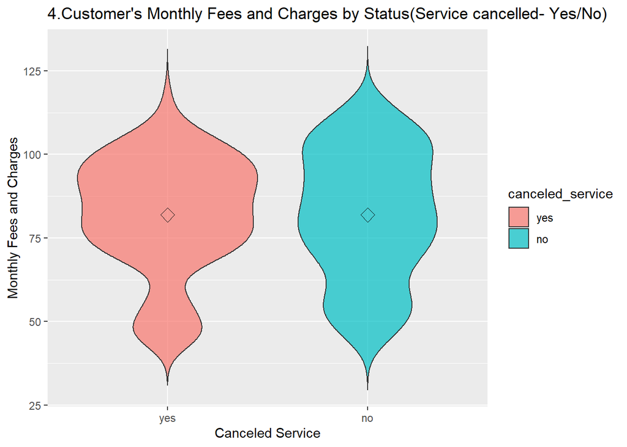

```r
ggplot(telecom_df, aes(canceled_service, monthly_charges)) +
  geom_violin(aes(fill = canceled_service), trim = FALSE, alpha=0.7) +
  stat_summary(fun = mean, geom ="point", shape = 23, size = 4) +
  labs(title = "4.Customer's Monthly Fees and Charges by Status(Service cancelled- Yes/No)",
           x = "Canceled Service", y = "Monthly Fees and Charges")
```

The Violin plot shows the distribution shape of the data. The width of the violin plot represents the density of the data points. Higher the width, the more the data points. It is observable from the above violin plot 4 that the density of customers throughout the plot with monthly fees and charges is almost the same for both the customers who either canceled or did not cancel the service. The mean monthly fees and charges are around $80 for both the customers who did or did not cancel the service.

# Question 5

**Question**: Is there a relation between service cancellation and device protection?

```r
telecom_df %>% group_by(canceled_service, device_protection) %>%
                  summarise(Num_Customers = n()) %>%
                  group_by(device_protection) %>%
                  mutate(Total_Cust_Dvc_Prot = sum(Num_Customers),
                  Perc_Dvc_Prot = round(Num_Customers/Total_Cust_Dvc_Prot, 2))
```

```
## # A tibble: 4 x 5
## # Groups:   device_protection [2]
##   canceled_service device_protecti~ Num_Customers Total_Cust_Dvc_~ Perc_Dvc_Prot
##   <fct>            <fct>                    <int>            <int>         <dbl>
## 1 yes              yes                        143              523          0.27
## 2 yes              no                         284              652          0.44
## 3 no               yes                        380              523          0.73
## 4 no               no                         368              652          0.56
```

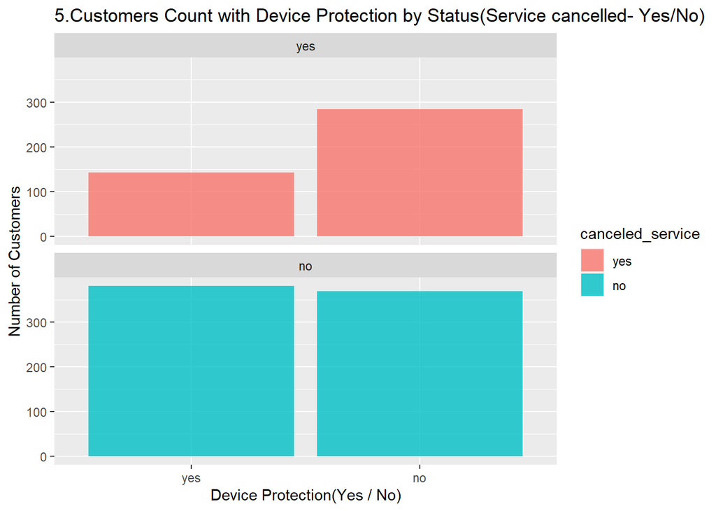

```r
telecom_df %>% group_by(canceled_service, device_protection) %>%
                  summarise(Num_Customers = n()) %>%
                  ggplot(aes(device_protection, Num_Customers, fill = canceled_service)) + geom_bar(stat = "identity", alpha=0.8) +
                  facet_wrap(~ canceled_service, nrow = 2) +
                  labs(title = "5.Customers Count with Device Protection by Status(Service cancelled- Yes/No)",
                  x = "Device Protection(Yes / No)", y = "Number of Customers")
```

The above bar plot 5 represents that the count of customers who did not cancel the service either with or without device protection is higher when compared to customers who did cancel the service.

# The telecom_df data is split into a training and testing set.

```r
set.seed(219)

telecom_split <- initial_split(telecom_df, prop = 0.75, strata = canceled_service)

telecom_train <- telecom_split %>% training()

telecom_test <- telecom_split %>% testing()
```

# Feature Engineering

```r
telecom_recipe <- recipe(canceled_service ~ ., data = telecom_train) %>%
                  step_YeoJohnson(all_numeric(), -all_outcomes()) %>%
                  step_normalize(all_numeric(), -all_outcomes()) %>%
                  step_dummy(all_nominal(), -all_outcomes())
```

```r
telecom_recipe %>% prep(training = telecom_train) %>% bake(new_data = NULL)
```

```
## # A tibble: 882 x 22
##    avg_call_mins avg_intl_mins months_with_com~ monthly_charges canceled_service
##            <dbl>         <dbl>            <dbl>           <dbl> <fct>
##  1       -0.620      -0.000889            0.334          -0.864 no
##  2       -1.10        0.646              -0.788          -1.69  no
##  3        0.0568     -1.45               -0.941           0.668 yes
##  4        0.238       2.31                1.23            0.450 no
##  5       -0.620      -0.971              -0.788          -0.381 no
##  6        0.0985     -0.877              -1.65            0.348 yes
##  7        2.13       -1.64                0.334           1.25  yes
##  8       -1.49        0.339              -1.34           -0.240 yes
##  9       -1.31       -1.48                0.588           1.25  no
## 10       -0.816      -0.813               1.34           -0.504 no
## # ... with 872 more rows, and 17 more variables: senior_citizen_no <dbl>,
## #   spouse_partner_no <dbl>, dependents_no <dbl>,
## #   cellular_service_single_line <dbl>, internet_service_digital <dbl>,
## #   online_security_no <dbl>, online_backup_no <dbl>,
## #   device_protection_no <dbl>, tech_support_no <dbl>, streaming_tv_no <dbl>,
## #   streaming_movies_no <dbl>, contract_one_year <dbl>,
## #   contract_two_year <dbl>, paperless_bill_no <dbl>,
## #   payment_method_credit_card <dbl>, payment_method_electronic_check <dbl>,
## #   payment_method_mailed_check <dbl>
```

# Model 1 : Logistic Regression

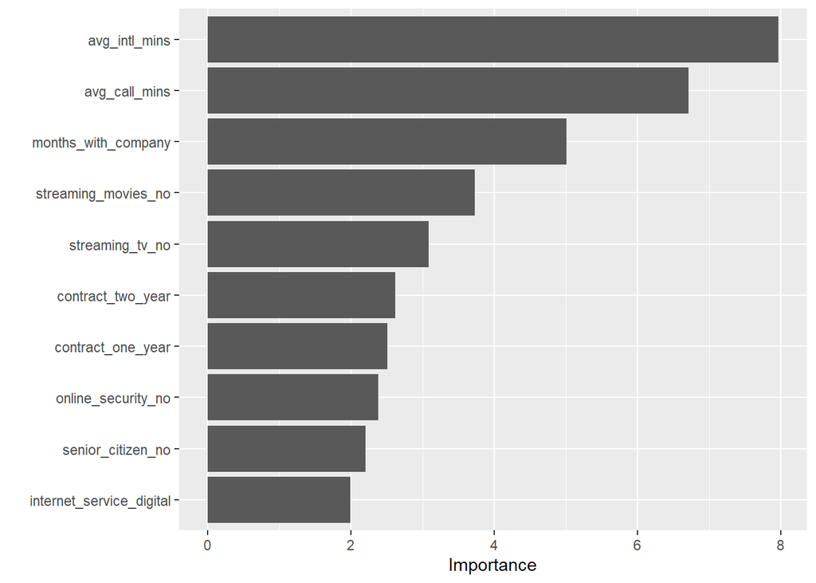

```r
# Specify a logistic regression model
logistic_model <- logistic_reg() %>%
                  set_engine('glm') %>%
                  set_mode('classification')

# Package recipe and model into a workflow
logistic_wf <- workflow() %>%
               add_model(logistic_model) %>%
               add_recipe(telecom_recipe)

# Fit the workflow to the training data
logistic_fit <- logistic_wf %>%
                fit(data = telecom_train)

# Let us explore the trained model
logistic_trained_model <- logistic_fit %>%
                          pull_workflow_fit()

# Variable importance plot
vip(logistic_trained_model)
```

Variable importance plot shows that attributes such as avg_intl_mins, avg_call_mins, months_with_company, and streaming_movies_no are more important than others in predicting the target variable canceled_service.

```r
# Let us predict the categories
logistic_pred_categories <- predict(logistic_fit, new_data = telecom_test)
logistic_pred_categories
```

```
## # A tibble: 293 x 1
##    .pred_class
##    <fct>
##  1 no
##  2 no
##  3 no
##  4 no
##  5 no
##  6 no
##  7 no
##  8 yes
##  9 yes
## 10 no
## # ... with 283 more rows
```

```r
# Examine predicted probabilities
logistic_probabilities <- predict(logistic_fit, new_data = telecom_test, type = 'prob')
logistic_probabilities
```

```
## # A tibble: 293 x 2
##    .pred_yes .pred_no
##        <dbl>    <dbl>
##  1    0.0505    0.949
##  2    0.438     0.562
##  3    0.497     0.503
##  4    0.167     0.833
##  5    0.0765    0.924
##  6    0.197     0.803
##  7    0.200     0.800
##  8    0.899     0.101
##  9    0.626     0.374
## 10    0.455     0.545
## # ... with 283 more rows
```

```r
# Combine with the true values
log_test_results <- telecom_test %>% select(canceled_service) %>%
                    bind_cols(logistic_pred_categories) %>%
                    bind_cols(logistic_probabilities)
log_test_results
```

```
## # A tibble: 293 x 4
##    canceled_service .pred_class .pred_yes .pred_no
##    <fct>            <fct>           <dbl>    <dbl>
##  1 no               no             0.0505    0.949
##  2 no               no             0.438     0.562
##  3 no               no             0.497     0.503
##  4 no               no             0.167     0.833
##  5 no               no             0.0765    0.924
##  6 no               no             0.197     0.803
##  7 no               no             0.200     0.800
##  8 yes              yes            0.899     0.101
##  9 no               yes            0.626     0.374
## 10 yes              no             0.455     0.545
## # ... with 283 more rows
```

```r
# Evaluate model performance

# Confusion Matrix
conf_mat(log_test_results, truth = canceled_service, estimate = .pred_class)
```

```
##           Truth
## Prediction yes  no
##        yes  76  24
##        no   30 163
```

The model predicted 24 false positives and 30 false negatives.

```r
# Sensitivity
sens(log_test_results, truth = canceled_service, estimate = .pred_class)
```

```
## # A tibble: 1 x 3
##   .metric .estimator .estimate
##   <chr>   <chr>          <dbl>
## 1 sens    binary         0.717
```

```r
# Specificity
spec(log_test_results, truth = canceled_service, estimate = .pred_class)
```

```
## # A tibble: 1 x 3
##   .metric .estimator .estimate
##   <chr>   <chr>          <dbl>
## 1 spec    binary         0.872
```

```r
# ROC Curve
roc_curve(log_test_results, truth = canceled_service, estimate = .pred_yes)
```

```
## # A tibble: 295 x 3
##    .threshold specificity sensitivity
##         <dbl>       <dbl>       <dbl>
##  1 -Inf           0                 1
##  2    0.00173     0                 1
##  3    0.00254     0.00535           1
##  4    0.00272     0.0107            1
##  5    0.00299     0.0160            1
##  6    0.00532     0.0214            1
##  7    0.00692     0.0267            1
##  8    0.00828     0.0321            1
##  9    0.0106      0.0374            1
## 10    0.0106      0.0428            1
## # ... with 285 more rows
```

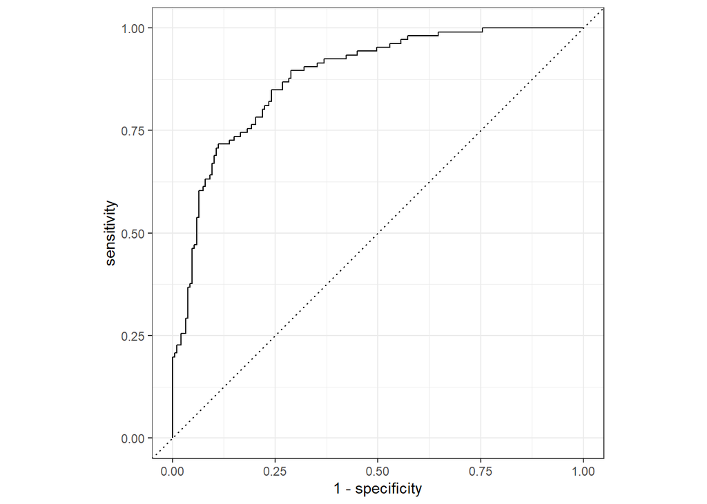

```r
# Plot ROC curve
roc_curve(log_test_results, truth = canceled_service, estimate = .pred_yes) %>%
  autoplot()
```

```r
# Calculate area under the ROC curve
roc_auc(log_test_results, truth = canceled_service, .pred_yes)
```

```
## # A tibble: 1 x 3
##   .metric .estimator .estimate
##   <chr>   <chr>          <dbl>
## 1 roc_auc binary         0.879
```

# Model 2 : Decision Tree

# Create folds for cross validation on the training set

```r
set.seed(219)

telecom_folds <- vfold_cv(telecom_train, v = 5)
```

```r
# Specify the decision tree classifier with the hyperparameters
tree_model <- decision_tree(cost_complexity = tune(),
                            tree_depth = tune(),
                            min_n = tune()) %>%
              set_engine('rpart') %>%
              set_mode('classification')

# Package recipe and model into a workflow
tree_wf <- workflow() %>%
           add_model(tree_model) %>%
           add_recipe(telecom_recipe)
```

```r
# Create a grid of hyperparameter values to test
tree_grid <- grid_random(parameters(tree_model),
                          size = 10)
tree_grid
```

```
## # A tibble: 10 x 3
##    cost_complexity tree_depth min_n
##              <dbl>      <int> <int>
##  1   0.0000150              4     8
##  2   0.0000000454           5    38
##  3   0.0000000524          13    37
##  4   0.0310                 7    40
##  5   0.0000263             14    20
##  6   0.0112                 9    24
##  7   0.0000000173           7     8
##  8   0.0000000916           3     4
##  9   0.00000000291          8    16
## 10   0.00000271             4     4
```

```r
# Tune decision tree workflow
set.seed(219)

tree_tuning <- tree_wf %>%
               tune_grid(resamples = telecom_folds, grid = tree_grid)
# Show the top 5 best models based on roc_auc metric
tree_tuning %>% show_best(metric = 'roc_auc')
```

```
## # A tibble: 5 x 9
##   cost_complexity tree_depth min_n .metric .estimator  mean     n std_err
##             <dbl>      <int> <int> <chr>   <chr>      <dbl> <int>   <dbl>
## 1   0.00000000291          8    16 roc_auc binary     0.796     5 0.0141
## 2   0.0000000524          13    37 roc_auc binary     0.793     5 0.00938
## 3   0.0000263             14    20 roc_auc binary     0.790     5 0.0144
## 4   0.0000000454           5    38 roc_auc binary     0.776     5 0.0110
## 5   0.00000271             4     4 roc_auc binary     0.768     5 0.0157
## # ... with 1 more variable: .config <chr>
```

```r
# Select best model based on roc_auc
best_tree <- tree_tuning %>%
             select_best(metric = 'roc_auc')
best_tree
```

```
## # A tibble: 1 x 4
##   cost_complexity tree_depth min_n .config
##             <dbl>      <int> <int> <chr>
## 1   0.00000000291          8    16 Preprocessor1_Model09
```

```r
# Finalize the workflow
final_tree_wf <- tree_wf %>%
                 finalize_workflow(best_tree)
```

```r
tree_wf_fit <- final_tree_wf %>%
            fit(data = telecom_train)
```

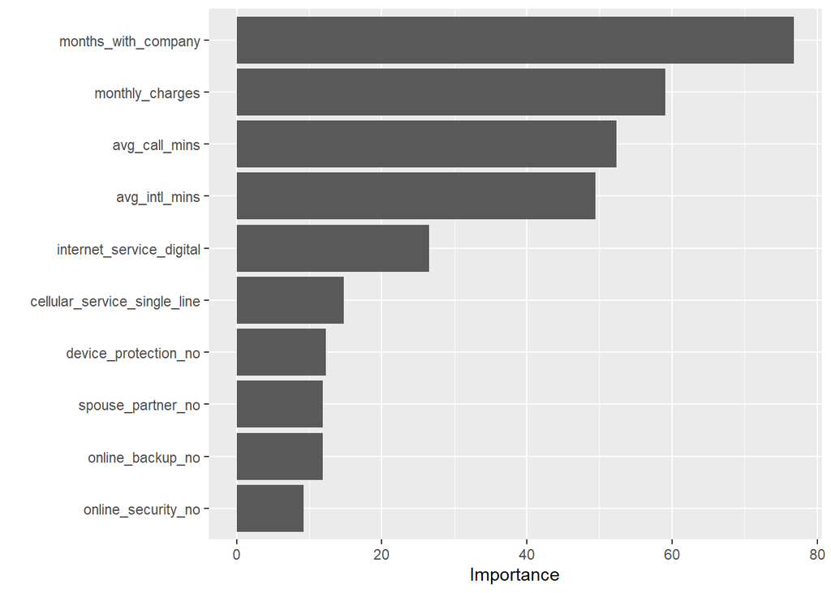

```r
tree_fit <- tree_wf_fit %>%
            pull_workflow_fit()

# Visualize variable importance
vip(tree_fit)
```

Variable importance plot shows that attributes such as months_with_company, monthly_charges, avg_call_mins, and avg_intl_mins are more important than others in predicting the target variable canceled_service.

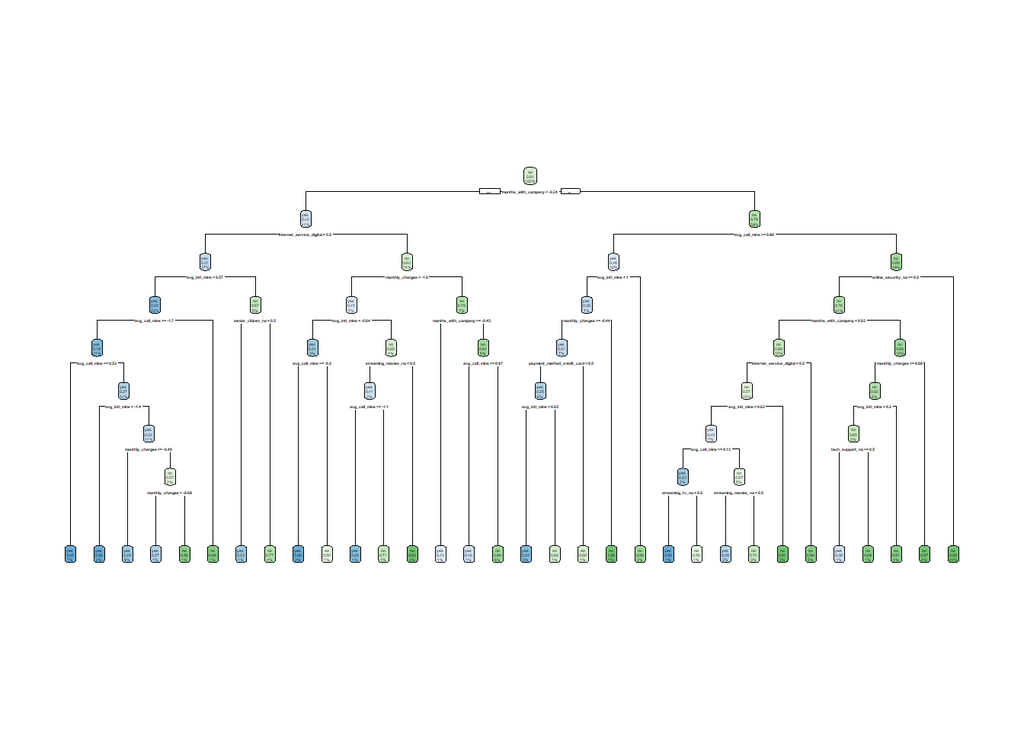

```r
# Let us visualize decision tree
rpart.plot(tree_fit$fit, roundint = FALSE)
```

```r
tree_last_fit <- final_tree_wf %>%
                 last_fit(telecom_split)
```

```r
# View performance metrics on test data
tree_last_fit %>% collect_metrics()
```

```
## # A tibble: 2 x 4
##   .metric  .estimator .estimate .config
##   <chr>    <chr>          <dbl> <chr>
## 1 accuracy binary         0.751 Preprocessor1_Model1
## 2 roc_auc  binary         0.808 Preprocessor1_Model1
```

```r
# Confusion Matrix
tree_predictions <- tree_last_fit %>% collect_predictions()

conf_mat(tree_predictions, truth = canceled_service, estimate = .pred_class)
```

```
##           Truth
## Prediction yes  no
##        yes  68  35
##        no   38 152
```

```r
# Sensitivity
sens(tree_predictions, truth = canceled_service, estimate = .pred_class)
```

```
## # A tibble: 1 x 3
##   .metric .estimator .estimate
##   <chr>   <chr>          <dbl>
## 1 sens    binary         0.642
```

```r
# Specificity
spec(tree_predictions, truth = canceled_service, estimate = .pred_class)
```

```
## # A tibble: 1 x 3
##   .metric .estimator .estimate
##   <chr>   <chr>          <dbl>
## 1 spec    binary         0.813
```

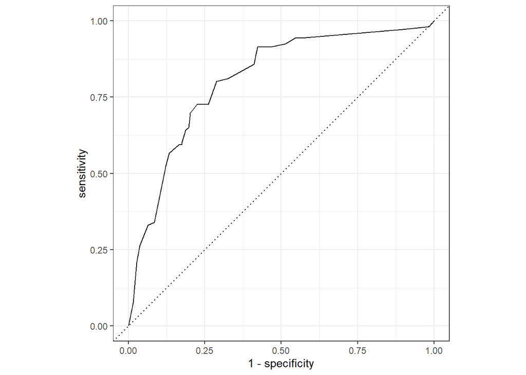

```r
# ROC curve
tree_predictions %>% roc_curve(truth = canceled_service, estimate = .pred_yes) %>%
                     autoplot()
```

```r
# Calculate area under the ROC curve
roc_auc(tree_predictions, truth = canceled_service, .pred_yes)
```

```
## # A tibble: 1 x 3
##   .metric .estimator .estimate
##   <chr>   <chr>          <dbl>
## 1 roc_auc binary         0.808
```

# Model 3 : Random Forest

```r
# Specify the random forest model
rf_model <- rand_forest(mtry = tune(),
                        trees = tune(),
                        min_n = tune()) %>%
            set_engine('ranger', importance = 'impurity') %>%
            set_mode('classification')

# Package recipe and model into a workflow
rf_wf <- workflow() %>%
         add_model(rf_model) %>%
         add_recipe(telecom_recipe)
```

```r
# Create a grid of hyperparameter values to test
set.seed(219)

rf_grid <- grid_random(mtry() %>% range_set(c(5, 15)),
                       trees(),
                       min_n(),
                       size = 10)
rf_grid
```

```
## # A tibble: 10 x 3
##     mtry trees min_n
##    <int> <int> <int>
##  1     5    16    20
##  2     6  1734    29
##  3    11   179    13
##  4    15   255    24
##  5    12  1834     2
##  6     6  1551    19
##  7    11  1224     5
##  8    10   314    28
##  9    15   894    24
## 10    14   306     9
```

```r
# Tune random forest workflow
set.seed(219)

rf_tuning <- rf_wf %>%
             tune_grid(resamples = telecom_folds, grid = rf_grid)
rf_tuning %>% show_best('roc_auc')
```

```
## # A tibble: 5 x 9
##    mtry trees min_n .metric .estimator  mean     n std_err .config
##   <int> <int> <int> <chr>   <chr>      <dbl> <int>   <dbl> <chr>
## 1     6  1551    19 roc_auc binary     0.868     5  0.0110 Preprocessor1_Model06
## 2     6  1734    29 roc_auc binary     0.867     5  0.0113 Preprocessor1_Model02
## 3    10   314    28 roc_auc binary     0.862     5  0.0121 Preprocessor1_Model08
## 4    11  1224     5 roc_auc binary     0.860     5  0.0113 Preprocessor1_Model07
## 5    11   179    13 roc_auc binary     0.860     5  0.0119 Preprocessor1_Model03
```

```r
# Select best model based on roc_auc
best_rf <- rf_tuning %>%
           select_best(metric = 'roc_auc')
best_rf
```

```
## # A tibble: 1 x 4
##    mtry trees min_n .config
##   <int> <int> <int> <chr>
## 1     6  1551    19 Preprocessor1_Model06
```

```r
# Finalize the workflow
final_rf_wf <- rf_wf %>%
               finalize_workflow(best_rf)
```

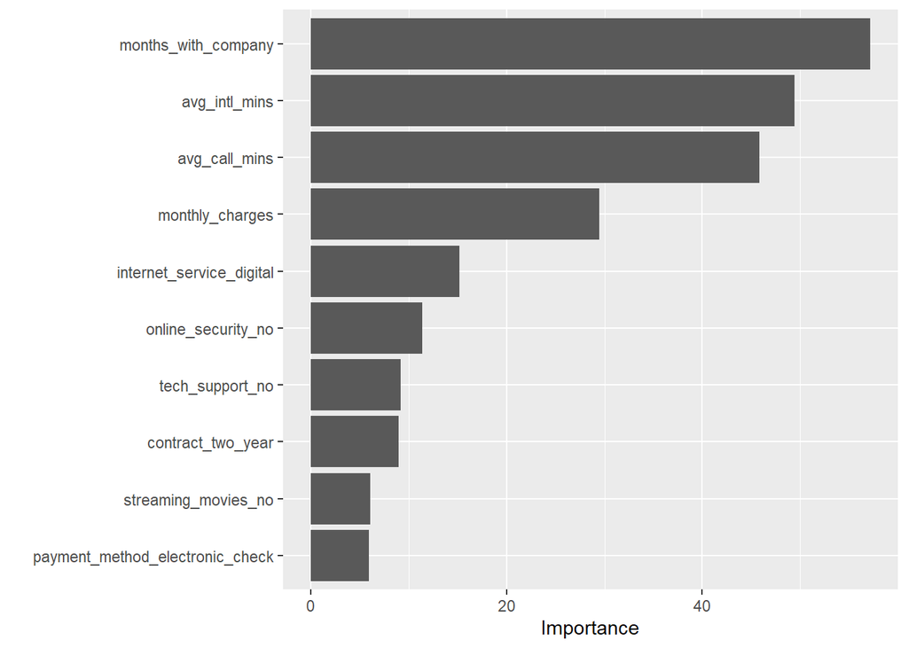

```r
# Fit randome forest model with training set
rf_wf_fit <- final_rf_wf %>%
             fit(data = telecom_train)

rf_fit <- rf_wf_fit %>%
          pull_workflow_fit()

# Visualize variable importance
vip(rf_fit)
```

Variable importance plot shows that attributes such as months_with_company, avg_intl_mins, avg_call_mins, and monthly_charges are more important than others in predicting the target variable canceled_service.

```r
# Train and evaluate with last_fit()
rf_last_fit <- final_rf_wf %>%
               last_fit(telecom_split)
```

```r
# View performance metrics on test data
rf_last_fit %>% collect_metrics()
```

```
## # A tibble: 2 x 4
##   .metric  .estimator .estimate .config
##   <chr>    <chr>          <dbl> <chr>
## 1 accuracy binary         0.788 Preprocessor1_Model1
## 2 roc_auc  binary         0.885 Preprocessor1_Model1
```

```r
# Confusion Matrix
rf_predictions <- rf_last_fit %>% collect_predictions()

conf_mat(rf_predictions, truth = canceled_service, estimate = .pred_class)
```

```
##           Truth
## Prediction yes  no
##        yes  65  21
##        no   41 166
```

Random Forest predicted 21 false positives and 41 false negatives.

```r
# Sensitivity
sens(rf_predictions, truth = canceled_service, estimate = .pred_class)
```

```
## # A tibble: 1 x 3
##   .metric .estimator .estimate
##   <chr>   <chr>          <dbl>
## 1 sens    binary         0.613
```

```r
# Specificity
spec(rf_predictions, truth = canceled_service, estimate = .pred_class)
```

```
## # A tibble: 1 x 3
##   .metric .estimator .estimate
##   <chr>   <chr>          <dbl>
## 1 spec    binary         0.888
```

# Note : From Confusion Matrix, we can calculate the error rate of the model as shown below.

# Type 1 error:

False positive rate = 21/(21+166) = 0.1122

#Type 2 error: False negative rate = 41/(65+41) = 0.3867

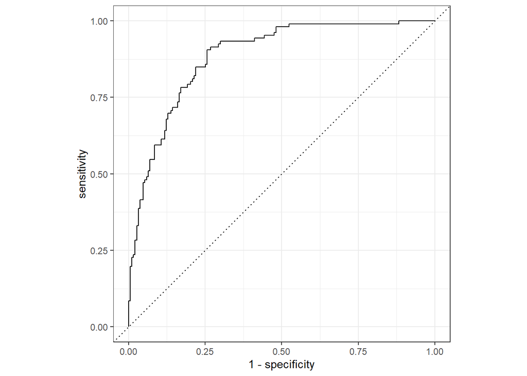

```r
# ROC curve
rf_predictions %>% roc_curve(truth = canceled_service, estimate = .pred_yes) %>%
                   autoplot()
```

```r
# Calculate area under the ROC curve
roc_auc(rf_predictions, truth = canceled_service, .pred_yes)
```

```
## # A tibble: 1 x 3
##   .metric .estimator .estimate
##   <chr>   <chr>          <dbl>
## 1 roc_auc binary         0.885
```

# ROC Curve

ROC curve represents the trade-off between true-positive rate and false-positive rate. Classifiers that take curves nearer to the top-left corner signify a better performance. The closer the curve moves to the diagonal line of the ROC space, the less accurate the test. When looking at ROC curves of Logistic regression, Decision tree, and Random forest, the random forest model performed the best.

# Area under ROC

The area under the ROC curve shows how much the model is capable of distinguishing between different classes. The higher the value of AUC, the better the model in predicting the classes as did or did not cancel the service. Out of all three models listed below, the AUC value of the random forest model is the highest. Hence, the random forest is the best model in predicting whether a customer canceled service or not. # Model Area under ROC 1. Logistic Regression 0.8794 2. Decision Tree 0.8084 3. Random Forest 0.8846